# Лекция 1. Введение и простые решения

# 1 Введение в дисциплину. Моделирование при исследовании скважин и пластов

## 1.1 Тезисы для лекции

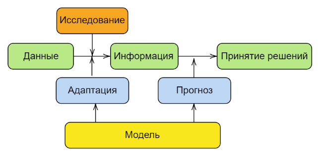

Связь исследований и моделирования через процесс принятия решений

1. Управление месторождениями строится на принятии решений. Принятие решений связано с необратимой тратой ресурсов с целью оптимизации некоторой целевой функции. Чаще всего целевая функция связана с экономикой проекта.
2. Исследования - инструмент для получения информации для принятия решений. Полезно разделить понятия данные и информация. Данные - то, что записано, информации - данные обработанные в контексте принятия решений.
3. Исследования основаны на моделях объекта управления. Модель - иструмент получения информации из данных. Также модель - инструмент принятия решений на основе информации. Модель - упрощенное представление реальности.
4. Модели используемые для принятия решений должны адекватно отражать реальность. Обеспечивается настройкой - адаптацией модели на известные данные и информацию. Такой процесс также можно считать исследованием. Почему?
5. Принятие решений на основе информации часто осуществляется на основе прогнозов - альтернативных вариантах принятия решений. Модель - инструмент для построения прогнозов.
6. В узком смысле - исследование скважины, в частности гидродинамические исследования - соответствуют адаптации специализированной модели - решения уравнения фильтрации. Адаптация готовит модель для построения прогнозов и принятия решений.
7. Понимание всей цепочки создания ценности от данных до принятия решений оказывается полезным, например для обоснования необходимости проведения исследований и оценки ценности информации получаемой в ходе исследований
8. Кроме понимания всей цепочки важно развитие навыков проведения расчетов - адаптации различных моделей, построения прогнозов с использованием этих моделей. Этому будет посвящена значительная часть курса.

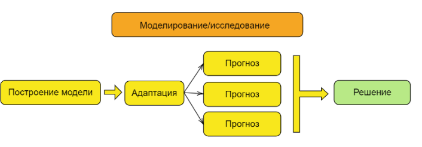

Схема принятия решений с использованием моделей.

## 1.2 Инструменты для моделирования

Работа с моделями в ходе курса может проводиться с использованием различного ПО

- python для построения аналитических моделей

  Для работы можно использовать jupyter notebook или google colab или любой другой сервис для работы со скважинами. Потребуется освоить базовые библиотеки python - numpy, scipy, matplotlib, mpmath, pandas. Также будут использованы некоторые другие специализированные библиотеки.
- Макросы MS Excel

  Часть расчетов можно выполнить с использованием макросов MS Excel, например Unifloc VBA (https://github.com/unifloc/unifloc_vba)
- Гидродинамический симулятор для построения численных моделей

  Базовый вариант - тНавигатор. Версия начиная от 19. Можно будет использовать другие симуляторы - РН-КИМ, Schlumberger eclipse, OPM и другие.
- Специализированное ПО для анализа ГДИС

  Возможно, что то появится в ходе курса.

# 2 Уравнение фильтрации

Уравнение фильтрации многофазного потока в пористой среде - основная математическая модель пласта используемая в инженерных приложениях. Используется не само уравнение, а разнообразные частные решения, описывающие те или иные ситуации. Наиболее широко известным примером решения уравнения фильтрации, возможно является, численное решение которое строится трехмерными гидродинамическими симуляторами (eclipse, tnavigator и так далее).

Как правило, при выводе уравнения фильтрации используются следующие соотношения:

1. закон Дарси - определяет линейную зависимость скорости фильтрации от давления

$$u_r=-\frac{k}{\mu}\frac{dp}{dr}
\tag{1}$$

2. уравнение неразрывности - или закон сохранения массы, показывает что в потоке не могут образовываться разрывы сплошности:
   $$\frac{1}{r}\frac{\partial\left(r\rho u_r\right)}{\partial r}=-\varphi\frac{\partial p}{\partial t}
   \tag{2}$$
3. уравнение состояния - задает зависимость плотности флюида от давления:
   $$c_0=\frac{1}{\rho}\frac{\partial\rho}{\partial p}
   \tag{3}$$

Опираясь на эти соотношения уравнение фильтрации в радиальной форме можно привести к виду для величин СИ.

$$\frac{\partial ^2 p }{\partial r^2} + \frac{1}{r} \frac{\partial p}{\partial r} = \frac{\varphi \mu c_t}{k} \frac{\partial p}{\partial t}
\tag{4}$$

Здесь используются следующие обозначения:

- $u_r$ - скорость фильтрации в направлении $r$, м/сек
- $k$ - проницаемость, м$^2$
- $\mu$ - вязкость флюида, Па с
- $p$ - давление, Па
- $r$ - расстояние, м
- $\rho$ - плотность флюида, кг/м$^3$
- $\varphi$ - пористость породы, доли единиц.
- $c_t$ - общая сжимаемость породы и флюида, 1/Па
- $t$ - время, сек

Иногда бывает удобно записать уравнение используя другие единицы измерения, например практические метрические - уравнение примет вид:

$$\frac{\partial ^2 p }{\partial r^2} + \frac{1}{r} \frac{\partial p}{\partial r} = \frac{\varphi \mu c_t}{0.00036 k} \frac{\partial p}{\partial t}
\tag{5}$$

- $k$ - проницаемость, мД
- $\mu$ - вязкость флюида, сП
- $p$ - давление, атм
- $r$ - расстояние, м
- $\rho$ - плотность флюида, кг/м$^3$
- $\varphi$ - пористость породы, доли единиц.
- $c_t$ - общая сжимаемость породы и флюида, 1/атм
- $t$ - время, час

Вывод уравнения фильтрации основан на следующих предположениях:

- пласт однородный и изотропный - пористость и проницаемость одинаковы во всем пласте и во всех направлениях и не зависят от давления
- добывающая скважина вскрывает весь продуктивный горизонт и обеспечивает радиальный приток к скважине
- пласт насыщен одним флюидом на всем протяжении
- температура не меняется в пласте, изотермичность

## 2.1 Вывод уравнения фильтрации для линейного потока

Уравнение фильтрации основано на трех основных уравнениях:

- законе сохранения массы
- зависимости связывающей градиент давления с расходом, в простейшем виде это закон Дарси
- уравнении состояния - зависимости связывающей сжимаемость флюида (и отчасти среды) и давлением

Выпишем эти уравнения, чтобы разобраться. Ориентируемся в обозначениях и подходе на [1]. Особое внимание на данном этапе стоит обратить на размерные коэффициенты в уравнениях. С одной стороны записывая уравнения в [СИ] их можно упростить и избежать части сложностей с переводными коэффициентами. С другой стороны во многих источниках переводные коэффициенты интесивно используются и это оказывается удобно при программной реализации алгоритмов. В данном описании ориентируясь на [1] приведем перевод коэффициентов в практические метрические единицы.

### 2.1.1 Закон сохранения массы

В дифференциальной форме, для потока в направлении $x$

$$-f \dfrac{\partial \rho q_x}{\partial x} = A \dfrac{\partial(\rho \phi)}{\partial t}
\tag{6}$$

где

- $f$ - размерный коэффициент, для практических метрических единиц $f= 0.04167$, для американских промысловых $f = 0.23394$
- $\rho$ - плотность флюида, кг/м$^3$, lbm/ft$^3$
- $q_x$ - объемный расход в направлении $x$, м$^3$/сут, bbl/day, учитываем для практических метрических единиц $1$ м$^3$/сут $= 0.04167$ м$^3$/час и для промысловых американских $1$ bbl/day $= 0.23394$ ft$^3$/hr
- x - координата, м, ft
- $\phi$ - пористость, доли единиц
- $t$ - время, часы
- $A$ - площадь, м$^2$, ft$^2$

В перечне указаны размерности для промысловых метрических и американских промысловых единиц измерений, там где они отличаются.

Для практических метрических единиц Уравнение 6 можно записать в виде
$$-0.04167 \dfrac{ \partial (\rho q_x) }{\partial x} = A \dfrac{\partial(\rho \phi)}{\partial t}
\tag{7}$$

### 2.1.2 Закон Дарси

Простейшим вариантом задания зависимости между измением давления и потоком флюида является линейная зависимость - закон Дарси. При этом линейный множитель в зависимости - функция как коллектора (проницаемость), так и свойств флюида (вязкость).

Закон Дарси в направлении $x$.
$$q_x = - \dfrac{k_x A}{f\mu} \dfrac{\partial p}{\partial x}
\tag{8}$$

где

- $f$ - размерный коэффициент, для практических метрических единиц $f= 115.74$, для американских промысловых $f = 887.2$
- $k_x$ - проницаемость в направлении движения потока, мД
- $A$ - площадь, м$^2$, ft$^2$
- $\mu$ - динамическая вязкость, сП
- $p$ - давление, атм, psi
- $x$ - координата движения потока, м

В практических метрических единицах измерения Уравнение 8 будет иметь вид
$$q_x = - \dfrac{k_x A}{115.74\mu} \dfrac{\partial p}{\partial x}
\tag{9}$$

Пытаясь проверить корректность вывода переводных коэффициентов необходимо учесть что для единиц измерение СИ получим $f=1$, а необходимые переводные коэффициенты можно записать как:

- $q$: $1$ [м$^3$/сек] = $543439$ [bbl/day] = $86400$ [м$^3$/сут]
- $k$: $1$ [м$^2$] = $1.01325 \cdot 10^{15}$ [мД]
- $\mu$: $1$ [Па$\cdot$с] = $1000$ [сП]
- $p$: $1$ [Па] = $0.0001450$ [psi] = $0.00000987$ [атм]
- $x$: $1$ [м] = $3.28$ [ft]
- $A$: $1$ [м$^2$] = $10.76$ [ft$^2$]

### 2.1.3 Уравнение состояния

В простейшем варианте, который мы будет изучать, предполагается, что сжимаемость постоянна и мала

$$c_t = c_{formation} + c_{fluid} = const
\tag{10}$$

- $c_t$ - общая сжимаемость (total compressibility)
- $c_{formation}$ - сжимаемость породы (formation compressibility), $c_{formation} = \dfrac{1}{\phi}\dfrac{\partial \phi}{\partial p}$
- $c_{fluid}$ - сжимаемость флюида (fluid compressibility), $c_{fluid} = \dfrac{1}{\rho}\dfrac{\partial \rho}{\partial p}$

### 2.1.4 Уравнение фильтрации

Подставим выражение для закона Дарси Уравнение 9 в уравнение мат баланса Уравнение 7

$$0.04167 \dfrac{ \partial}{\partial x} { \left[ \rho \dfrac{k_x A}{115.74\mu} \dfrac{\partial p}{\partial x} \right] } = A \dfrac{\partial(\rho \phi)}{\partial t}
\tag{11}$$

Упрощая Уравнение 11 получим

$$\frac{\partial (\rho \phi)}{\partial t} = 0.00036 k_x \dfrac{ \partial}{\partial x}\left[ \dfrac{\rho}{\mu}\dfrac{\partial p}{\partial x} \right]
\tag{12}$$

Уравнение 12 подходит для потока газа. Для жидкости, предполагая малую сжимаемость флюида можно его упростить до вида

$$\frac{\partial p}{\partial t} = 0.00036 \dfrac{k_x}{\phi \mu c_t} \dfrac{ \partial^2 p}{\partial x^2}
\tag{13}$$

Напомним, здесь

- $p$ - давление, атм
- $t$ - время, час
- $k_x$ - проницаемость в направлении движения потока, мД
- $\mu$ - динамическая вязкость, сП
- $\phi$ - пористость, д.е.
- $c_t$ - сжимаемость, 1/атм
- $x$ - расстояние, м

Приведенное Уравнение 13 соответствует линейному потоку в пласте. Практический интерес представляет решение для радиального потока

## 2.2 Вывод уравнения фильтрации для радиального потока

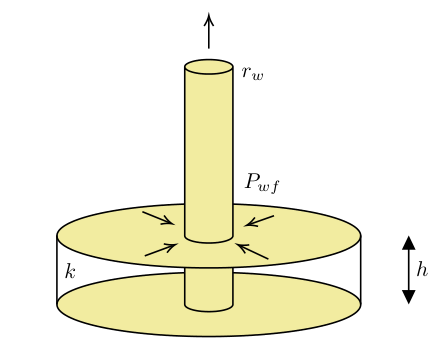

Схема радиального притока к скважине

### 2.2.1 Закон сохранения массы

Закон сохранения массы или принцип неразрывности можно выразить в радиальной форме следующим соотношением

$$\frac{1}{r}\frac{\partial\left(r\rho u_r\right)}{\partial r}=-\varphi\frac{\partial p}{\partial t}
\tag{14}$$

Принцип неразрывности показывает, что для определенного объема пласта, масса флюида которое втекла в контрольный объем пласта минус масса которая вытекла равна массе которая накопилась в объеме.

Сохранение импульса или закон Дарси можно выразить соотношением

$$u_r=-\frac{k}{\mu}\frac{d^p}{dr}
\tag{15}$$

Закон Дарси здесь используется как псевдоустановившаяся аппроксимация обобщенного уравнения сохранения импульса (то есть слагаемым отвечающим за накопление импульса пренебрегаем). Это предположение справедливо если не учитывать возмущения давления в среде двигающиеся со скоростью звука. Все изменения давления описываемые моделью связаны с локальными изменениями градиента давления за счет ламинарного режима потока. Хотя далее в модели будет учтена сжимаемость системы всеми “звуковыми” эффектами в системе мы пренебрегаем.

Поток предполагается горизонтальным, поэтому давление $p$ может быть использовано в качестве потенциала потока, гравитационными силами пренебрегаем.

Комбинируя Уравнение 14 , Уравнение 15 получим:

$$\frac{1}{r}\frac{\partial\left( \dfrac{r\rho k}{\mu}\dfrac{\partial p}{dr}\right)}{\partial r}=\varphi\frac{\partial \rho}{\partial t}
\tag{16}$$

Уравнение 16 – дифференциальное уравнение в частных производных описывающее нестационарный поток однофазного флюида в пористой среде при ламинарном потоке.

Вообще говоря приведенное уравнение является нелинейным, так как плотность $\rho = \rho(p)$ и вязкость $\mu = \mu(p)$ являются функциями давления. Уравнение содержит две зависимые переменные - давление $p$ и плотность $\rho$. Поэтому для его решения необходимо задать еще одно соотношение, каковым может быть уравнение состояния флюида связывающее плотность флюида и давление $\rho = \rho(p)$.

### 2.2.2 Флюид постоянной сжимаемости

Нестационарное поведение давления в пласте связано со сжимаемостью системы. При изменении давления в какой то точке, часть флюида сжимается, происходит накопление или отдача флюида, что вызывает задержку в распространении изменения флюида. Несмотря на то, что сжимаемость флюидов и породы малы и во многих случаях ими можно пренебречь, это не верно для пластовых систем для добычи нефти. Большие объемы пласта и флюидов и высокие давления компенсируют малость сжимаемости и требуют ее учета.

Для однофазного флюида разумным является предположение постоянства сжимаемости.

Сжимаемость можно определить как

$$c=-\frac{1}{V} \left( \frac{ \partial V}{ \partial p} \right)$$

учтем, что

$$\rho = \frac{m}{V}$$

тогда получим

$$c=\frac{1}{\rho} \left( \frac{ \partial \rho}{ \partial p} \right)$$

Для флюида с постоянной сжимаемостью, проинтегрировав приведенное уравнение можно получить

$$\rho = \rho_i e^{c(p-p_i)}$$

где $\rho_i$ плотность флюида при некотором заданном давлении $p_i$

Продифференцировав выражение для плотности по времени получим

$$c \rho \frac{\partial p}{\partial t} = \frac{\partial \rho}{\partial t}$$

Подставив это выражение в ранее полученное уравнение фильтрации (Уравнение 16) получим

$$\frac{1}{r}\frac{\partial\left( \dfrac{r\rho k}{\mu}\dfrac{\partial p}{dr}\right)}{\partial r}=\varphi c \rho \frac{\partial p}{\partial t}
\tag{17}$$

Приведенное дифференциальное уравнение в частных производных все еще нелинейно, поскольку зависит от плотности $\rho$

### 2.2.3 Общая сжимаемость

Если пористость не является постоянной величиной и меняется с давлением, тогда слагаемое отвечающее за накопление флюида в пласте можно выразить как

$$\frac{\partial \varphi \rho}{\partial t} = \varphi \frac{\partial \rho}{\partial t}+ \rho \frac{\partial \varphi }{\partial t} = \varphi c_l \rho \frac{\partial p}{\partial t} + \rho \frac{\partial \varphi }{\partial t}$$

где $c_l$ сжимаемость жидкости.

Определим сжимаемость породы как

$$c_f = \frac{1}{\varphi} \frac{\partial \varphi}{\partial p}$$

тогда

$$\frac{\partial \varphi \rho}{\partial t} = \varphi \rho (c_l + c_f) \frac{\partial p}{\partial t}$$

хотя пористость здесь является функцией давления - в первом приближении мы можем считать ее константой равной пористости при некотором среднем давлении в пласте. Это справедливо для маленькой сжимаемости породы, что верно почти всегда.

Уравнение для сжимаемости можно еще уточнить, учтя что в пласте могут находится различные флюиды - вода и нефть с насыщенностями $s_w$ и $s_o$

тогда

$$c_l = s_o c_o + s_w c_w$$

тогда можно ввести общую сжимаемость системы

$$c_t = c_l + c_f = s_o c_o + s_w c_w + c_f$$

Заметим, что проницаемость k в законе Дарси это не абсолютная проницаемость, но относительная проницаемость по нефти при насыщенности водой соответствующей связанной воде.

$$k= k_o (s_{wc})$$

### 2.2.4 Линеаризация уравнения фильтрации

Раскрыв производную в левой части Уравнение 17 и предположив, что $\dfrac{\partial p}{\partial r}$ мало а следовательно слагаемым $r \rho c_t \left( \dfrac{\partial p}{\partial r} \right)^2$ можно пренебречь, получим линеаризованное уравнения фильтрации

$$\frac{\partial^2 p}{\partial r^2} + \frac{1}{r} \frac{\partial p}{\partial r}= \frac{\varphi \mu c_t}{k} \frac{\partial p}{\partial t}
\tag{18}$$

## 2.3 Безразмерные переменные

Часто для анализа уравнений неустановившейся фильтрации используются безразмерные переменные. Мы будем использовать переменные в виде:

$$r_D = \frac{r}{r_w}$$

$$t_D = \frac{kt}{\varphi \mu c_t r_w^2}$$

$$p_D = \frac{2 \pi kh}{q_s B \mu} \left( p_i - p_{wf} \right)$$

$$q_D = \frac{q}{q_{ref}}$$

Здесь использованы единицы измерения СИ.

- $q_s$ - дебит скважины на поверхности, приведенный к нормальным условиям м3/с
- $\varphi$ - пористость, доли единиц
- $\mu$ - вязкость нефти в пласте, Па с
- $B$ - объемный коэффициент нефти, м3/м3
- $p_i$ - начальное давление в пласте, Па
- $p_{wf}$ - давление забойное, Па
- $c_t$ - общая сжимаемость системы в пласте, 1/Па

Использование безразмерных переменных позволяет упростить уравнение фильтрации, которое примет вид

$$\frac{\partial p_D}{ \partial t_D} = \frac{1}{r_D} \frac{ \partial{ \left( r_D \dfrac{\partial p_D}{ \partial r_D} \right) } }{ \partial{r_D} }$$

$$\frac{\partial p_D}{ \partial t_D} = \dfrac{1}{r_D} \left[ \dfrac{\partial}{\partial r_D} \left( r_D \dfrac{ \partial p_D} {\partial r_D} \right) \right]$$

Решение этого уравнения - функция безразмерного давления от безразмерных времени и расстояния $p_D(r_D, t_D)$

Для практических расчетов удобнее бывает использовать безразмерные переменные полученные для практических метрических единиц измерения.
$$r_D = \frac{r}{r_w}$$

$$t_D = \frac{0.00036 kt}{\varphi \mu c_t r_w^2}$$

$$p_D = \frac{kh}{ 18.4 q_s B \mu} \left( p_i - p_{wf} \right)$$

$$q_D = \frac{q}{q_{ref}}$$

Здесь использованы практические метрические единицы измерения.

- $q_s$ - дебит скважины на поверхности, приведенный к нормальным условиям м3/сут
- $\varphi$ - пористость, доли единиц
- $\mu$ - вязкость нефти в пласте, сП
- $B$ - объемный коэффициент нефти, м3/м3
- $p_i$ - начальное давление в пласте, атм
- $p_{wf}$ - давление забойное, атм
- $c_t$ - общая сжимаемость системы в пласте, 1/атм

Уравнение фильтрации для радиального потока в линеаризованном виде можно записать в виде

$$\frac{\partial p}{\partial t} = 0.00036 \dfrac{k}{\phi \mu c_t} \dfrac{1}{r} \left[ \dfrac{\partial}{\partial r} \left( r \dfrac{ \partial p} {\partial r} \right) \right]$$

Использование безразмерных переменных позволяет упростить уравнение фильтрации, которое примет вид

$$\frac{\partial p_D}{ \partial t_D} = \dfrac{1}{r_D} \left[ \dfrac{\partial}{\partial r_D} \left( r_D \dfrac{ \partial p_D} {\partial r_D} \right) \right]$$

Решение этого уравнения - функция безразмерного давления от безразмерных времени и расстояния $p_D(r_D, t_D)$

### 2.3.1 Расчет безразмерных переменных в Unifloc VBA

Несмотря на простоту определений безразмерных переменных их часто приходится применять при проведении расчетов. Поэтому в надстройке Unifloc VBA реализован набор функций расчета безразмерных переменных.

Эти функции начинаются с префикса transient_def.

```
    transient_def_cd
    transient_def_cs_1atm
    transient_def_td
    transient_def_t_day
    transient_def_pd
    transient_def_pwf_atma
```

Описания функций и из аргументов можно найти в руководстве пользователя Unifloc VBA

# 3 Стационарные решения уравнения фильтрации

Широкое распространение на практике получили стационарные решения уравнения фильтрации. Приведем некоторые из них.

## 3.1 Решение для постоянного давления на круговой границе

Рассматривается самая простая модель работы добывающей скважины - радиальная стационарная фильтрация в однородном изотропном пласте круговой формы. Скважина находится в центре пласта (Рисунок 1). На границе пласта поддерживается постоянное давление. Фактически это означает, что через границу пласта идет поток жидкости, уравновешивающий дебит скважины.

Решение можно получить как решения уравнения фильтрации, учитывая стационарность потока

$$\frac{\partial ^2 p }{\partial r^2} + \frac{1}{r} \frac{\partial p}{\partial r} = 0
\tag{19}$$

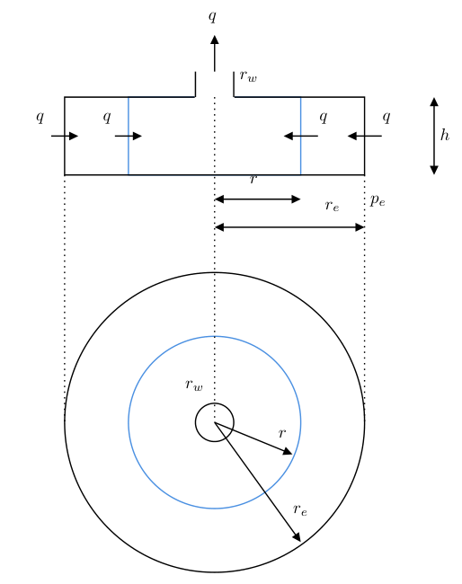

Рисунок 1: Схема радиального притока к скважине при наличии постоянного давления на границе

Или можно получить его непосредственно из закона Дарси, который должен быть приведен к радиальной форме и в таком варианте известен как Формула Дюпюи. Для приведенной конфигурации можно записать закон Дарси в форме.

$$u_r=\frac{q}{2\pi rh}=\frac{k}{\mu}\frac{dP}{dr}$$

Проинтегрировав выражение по замкнутому контуру радиуса $r_e$ вокруг скважины получим выражение известное как формула Дюпюи

$$q=\frac{2\pi kh\left(P_e-P_w\right)}{\mu\left(\ln{\dfrac{r_e}{r_w}}\right)}
\tag{20}$$

В приведенном выражения использованы единицы СИ.

Здесь

- $u_r$ - приведенная скорость фильтрации на расстоянии $r$ от скважины, м/с
- $q$ - объемные дебит скважины в рабочих условиях, м$^3$/с
- $r$ - радиус - расстояние от центра скважины, м
- $r_e$ - радиус зоны дренирования, на котором поддерживается постоянное давление, м
- $r_w$ - радиус скважины, на котором замеряется забойное давление, м
- $P$ - давление, Па
- $P_e$ - давление на внешнем контуре дренирования, Па
- $P_w$ - давление на забое скважины, Па
- $k$ - проницаемость, м$^2$
- $\mu$ - вязкость нефти в зоне дренирования, Па с

На практике часто бывает удобнее пользоваться значениями в практических метрических единицах измерения.

$$q=\frac{kh\left(P_e-P_w\right)}{ 18.4 \mu\left(\ln{\dfrac{r_e}{r_w}}\right)}
\tag{21}$$

где

- $q$ - объемные дебит скважины в рабочих условиях, м$^3$/сут
- $r$ - радиус - расстояние от центра скважины, м
- $r_e$ - радиус зоны дренирования, на котором поддерживается постоянное давление, м
- $r_w$ - радиус скважины, на котором замеряется забойное давление, м
- $P$ - давление, атм
- $P_e$ - давление на внешнем контуре дренирования, атм
- $P_w$ - давление на забое скважины, атм
- $k$ - проницаемость, мД
- $\mu$ - вязкость нефти в зоне дренирования, сП

Далее если не указано особо будем использовать практические метрические единицы.

### 3.1.1 Учет скин-фактора

Скин-фактор — гидродинамический параметр, характеризующий дополнительное фильтрационное сопротивление течению флюидов в околоскважинной зоне пласта, приводящее к изменению добычи (дебита) по сравнению с совершенной (идеальной) скважиной. Скин-фактор может приводить как к снижению дебита (например при загрязнении ПЗС), так и увеличению (образование высокопроводящих каналов в ПЗС).

Концепция скин-фактора получила широкое распространение на практике. Все инженеры-нефтяники знают этот параметр и оперируют им на практике.

Изначально скин-фактор был введен как параметр учитывающий изменение проницаемости (загрязнение) призабойной зоны при расчете производительности скважины. Такое загрязнение может быть вызвано различными причинами:

- проникновением бурового раствора в пласт и блокировкой поровых каналов;
- набуханием глин при контакте с фильтратом бурового раствора;
- химическим осаждением элементов бурового раствора, жидкости глушения или пластовых флюидов в призабойной зоне скважины, например осаждением солей или асфальтенов;
- продвижением песчаных частиц к стволу скважины;
- повреждением породы при перфорации;
- другими причинами.

Для модели загрязненной призабойной зоны величину скин-фактора можно выразить формулой Хокинса . Скин-фактор для плоскорадиального установившегося потока несжимаемой жидкости:

$$S =\left( \frac{k}{k_s} -1\right)\ ln\frac{r_s}{r_w}
\tag{22}$$

здесь:

- $k_s$ - проницаемость в загрязненной ПЗП;
- $k$ - однородная проницаемость по всему пласту;
- $r_s$ - радиус загрязненной зоны;
- $r_w$ - радиус скважины.

Концепция скин-фактора оказалась удобной для описания характеристики соединения скважины и пласта и была распространена на другие случаи, когда производительность скважины могла отличаться от производительности идеальной скважины:

- для горизонтальных скважин;
- для скважин вскрывающих пласт под углом;
- для скважин пересеченных трещиной ГРП;
- для скважин вскрытых перфорацией и учета гидравлического сопротивления потока на перфорационных отверстиях;
- другими причинами.

Для многих подобных случаев предположение о радиальном притоке к скважине не верно, но величину скин-фактора используют, так как она позволяет сравнить производительность скважины со сложным заканчиванием с простой вертикальной скважиной. В таких случая говорят о псевдорадиальном скин-факторе - такой величине скин-фактора $S$, которая обеспечила бы такую же производительность для вертикальной скважины полностью вскрывающей пласт.

Для стационарной радиальной модели притока учет скин-фактора приведен к следующим соотношениям:

$$(P_e - P_{wf}) = \frac{18.41\mu q }{\ k h}(\ln\frac{r_e}{r_w}+S)
\tag{23}$$

$$q=\frac{kh\left(P_e-P_w\right)}{ 18.41 \mu\left(\ln{\dfrac{r_e}{r_w}} + S\right)}
\tag{24}$$

### 3.1.2 Решение для постоянного давления на круговой границе с учетом среднего давления в области дренирования

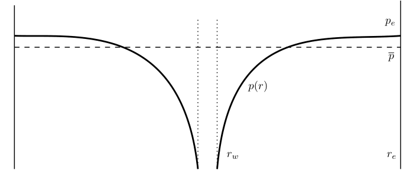

Рисунок 2: Среднее давление в области дренирования

В этом случае выражение для дебита примет вид
$$q=\frac{kh\left( \bar{P}-P_w\right)}{ 18.41 \mu\left(\ln{\dfrac{r_e}{r_w}} - \dfrac{1}{2}+ S \right)}$$

## 3.2 Решение для круговой непроницаемой границы

Схема модели радиального притока для условия непротекания на круговой границе приведена на Рисунок 3

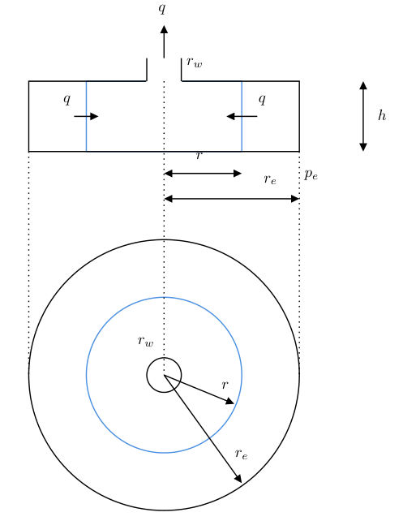

Рисунок 3: Схема радиального притока к скважине при наличии непроницаемой границы

При условии непротекания давления на границе условия стационарности (неизменности давления) не достигаются. При работе скважины с постоянным дебитом забойное давление будет постоянно снижаться. Однако начиная с некоторого момента, когда влияние скважины достигнет границ - давление в всей области дренирования начнет снижаться равномерно (смотри Рисунок 4).

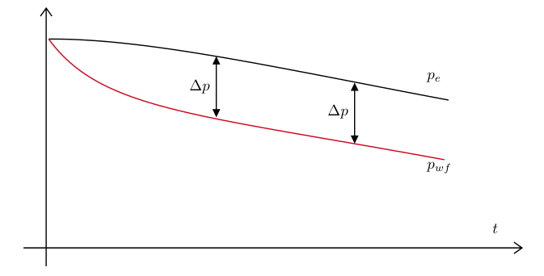

Рисунок 4: Изменение давления на границе и на забое скважины во времени

Такой режим, при котором забойное давление меняется, но перепад давления $P_e - P_w$ остается постоянным называют псевдо-установившимся режимом работы (pss - pseudo steady state).

Для псевдо-установившегося режима можно записать выражение

$$q=\frac{kh\left(P_e-P_w\right)}{ 18.41 \mu\left(\ln{\dfrac{r_e}{r_w}} - \dfrac{1}{2} + S\right)}$$
где

- $q$ - объемные дебит скважины в рабочих условиях, м3/сут;
- $r$ - радиус - расстояние от центра скважины, м;
- $r_e$ - радиус зоны дренирования, на котором поддерживается постоянное давление, м;
- $r_w$ - радиус скважины, на котором замеряется забойное давление, м;
- $P$ - давление, атм;
- $P_e$ - давление на внешнем контуре дренирования, атм;
- $P_w$ - давление на забое скважины, атм;
- $k$ - проницаемость, мД;
- $\mu$ - вязкость нефти в зоне дренирования, сП.

### 3.2.1 Решение для круговой непроницаемой границы с учетом среднего давления в зоне дренирования

Аналогично случаю для постоянного давления на границе можно переписать выражение с использованием среднего давления в области дренирования.

$$q=\frac{kh\left( \bar{P}-P_w\right)}{ 18.41 \mu\left(\ln{\dfrac{r_e}{r_w}} - \dfrac{3}{4}+ S \right)}$$

### 3.2.2 Стационарные решения для вертикальной скважины в резервуаре произвольной формы

Здесь уравнения и методы расчета для горизонтальных, наклонно направленных скважин, скважин с ГРП, горизонтальных скважин с МГРП.

$$q=\frac{kh\left( \bar{P}-P_w\right)}{ 18.41 \mu\left(\ln{\dfrac{2.2458 A}{C_A r_w^2}} + S \right)}$$

- $q$ - объемные дебит скважины в рабочих условиях, м3/сут;
- $A$ - площадь области дренирования, м$^2$;
- $C_A$ - фактор формы, зависит от формы резервуара и расположения скважины;
- $r_w$ - радиус скважины, на котором замеряется забойное давление, м;
- $\bar{P}$ - среднее давление в области дренирования, атм;
- $P_e$ - давление на внешнем контуре дренирования, атм;
- $P_w$ - давление на забое скважины, атм;
- $k$ - проницаемость, мД;
- $\mu$ - вязкость нефти в зоне дренирования, сП.

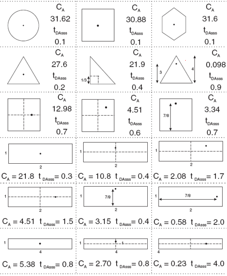

Рисунок 5: Значения фактора формы

Безразмерное время достижения псевдо-установившегося режима притока, определяемое видом резервуара

$$t_{DApss} = \frac{kt_{pss}}{\varphi \mu c_t A}$$

## 3.3 Формула Дюпюи

Простое решение для задачи стационарного притока к вертикальной скважине в однородном изотропном пласте круговой формы с постоянным давлением на границе имеет вид

$$Q=\dfrac{kh}{18.41\mu B} \dfrac{P_{res}-P_{wf}}{\ln \dfrac{r_e}{r_w} + S}$$

где:

- $Q$ - дебит скважины на поверхности, приведённый к нормальным условиям, ст. м$^3$/сут
- $\mu$ - вязкость нефти в пласте, сП
- $B$ - объёмный коэффициент нефти, м$^3$/м$^3$
- $P_{res}$ - пластовое давление или давление на контуре с радиусом $r_e$, атма
- $P_{wf}$ - давление забойное, атма
- $k$ - проницаемость, мД
- $h$ - мощность пласта, м
- $r_e$ - внешний контур дренирования скважины, м
- $r_w$ - радиус скважины, м
- $S$ - скин-фактор скважины, м

Это решение известно как закон Дарси или формула Дюпюи.

Выражение можно переписать в виде

$$P_{r} = P_{res} - 18.41\dfrac{ Q\mu B }{kh} \left[ \ln\dfrac{r_e}{r} +S \right]$$

Выражение можно переписать
$$P_{r} = P_{wf} + 18.41\dfrac{ Q\mu B }{kh} \left[ \ln\dfrac{r}{r_w} +S \right]$$

где по известному дебиту и забойному давлению можно найти давление в пласте. При известном пластовом давлении можно оценить радиус контура на котором оно достигается.

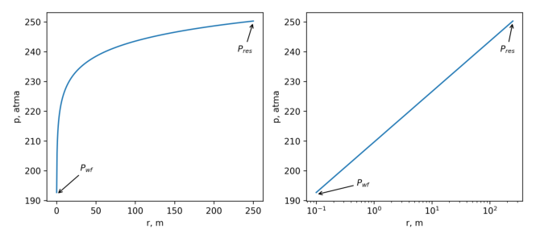

Рисунок 6: Распределение давления в круговом пласте

### 3.3.1 Формула Дюпюи в декартовых координатах

Для построения карты распределения давлений в пласте полезно вспомнить, что расстояние от скважины с координатами $(x_{well}, y_{well})$ до произвольной точки пласта с координатами $(x,y)$ можно найти по формуле
$$r=\sqrt{ (x-x_{well})^2 + (y-y_{well})^2 }$$

Тогда выражение для расчета давления в любой точке пласта примет вид

$$P_{r} = P_{res} - 18.41\dfrac{ Q\mu B }{kh} \left[ \ln\dfrac{r_e}{\sqrt{ (x-x_{well})^2 + (y-y_{well})^2 }} +S \right]$$

Простой вариант расчета - можно создать пустую матрицу со значениями давления по сетке и перебирая все точки на сетке/матрице рассчитать давления

## 3.4 Суперпозиция для стационарного решения

### 3.4.1 Суперпозиция для нескольких скважин с постоянным дебитом

Для стационарного решения работает принцип суперпозиции - сумма двух решений также будет решением, это позволяет построить карту для нескольких скважин. Давление в любой точке пласта можно найти по формуле

$$P_{res} - P_{x,y} = \sum_{i} 18.41\dfrac{ Q_i\mu B }{kh} \left[ \ln\frac{r_e}{\sqrt{ (x-x_{w.i})^2 + (y-y_{w.i})^2 }} +S \right]$$

Выражение справедливо только если $\sqrt{ (x-x_{w.i})^2 + (y-y_{w.i})^2 }< r_e$.

### 3.4.2 Суперпозиция для нескольких скважин с постоянным забойным давлением

При наличии нескольких скважин можно записать выражение для оценки забойных давлений скважин

$$P_{res} - P_{wf.j} = \sum_{i} 18.41\dfrac{ Q_i\mu B }{kh} \left[ \ln\dfrac{r_e}{\sqrt{ (x_{w.j}-x_{w.i})^2 + (y_{w.j}-y_{w.i})^2 }} +S \right]$$

$$AX = B$$

Где
$$A_{[i,j]} = 18.41\dfrac{ \mu B }{kh} \left[ \ln\dfrac{r_e}{\sqrt{ (x_{w.j}-x_{w.i})^2 + (y_{w.j}-y_{w.i})^2 }} +S \right]$$

$$B_{[j]}=P_{res} - P_{wf.j}$$

такую систему можно решить например с использованием пакета `scipy.linalg`

## 3.5 Производительность скважины

Уравнение производительности скважины можно записать в виде

$$Q = T \Delta P J_D
\tag{25}$$

где

- $Q$ - дебит жидкости скважины на поверхности, приведенный к стандартным условиям, м$^3$/сут.
  $$Q = qB$$
- $T$ - параметр зависящий от гидропроводности пласта
  $$T=\dfrac{18.41\mu B q }{\ k h}
  \tag{26}$$
- $\Delta P$ - депрессия на пласт, атм
  $$\Delta P = \left(P_e-P_w\right)
  \tag{27}$$
- $J_D$ - безразмерный коэффициент продуктивности скважины,
  $$J_D = \dfrac{1}{ \left(\ln{\dfrac{r_e}{r_w}} + S\right)}
  \tag{28}$$

Уравнение 25 можно интерпретировать следующим образом. Параметр $T$ отвечает за свойства пласта и флюида на которые трудно повлиять в ходе эксплуатации. Это то, что дала природа в точке где находится скважина. Депрессия $\Delta P$ – параметр которым можно управлять в ходе эксплуатации регулируя забойное давление. Например за счет установки насоса и задания параметров его работы. На этом параметре должно быть сосредоточено основное внимание при анализе работы скважины. Параметр $J_D$ – определяет качество соединения скважины с пластом или качество заканчивания. Его мы можем выбирать при строительстве скважины и можем менять в ходе эксплуатации проводя ГТМ, хотя и достаточно большой ценой. Поскольку мы можем влиять на $J_D$ важно понимать, какое оптимальное значение продуктивности можно достичь на конкретной скважине и как его можно изменить.

Задачей гидродинамических исследований является установление величин $T$ и $J_D$, хотя традиционно речь ведется об определении проницаемости $k$ и скин-фактора $S$.

## 3.6 Задания для самостоятельной работы

Для совершенствования навыков работы с python выполните следующие задания:

1. Постройте график распределения давления в пласте для композитного пласта. В композитном пласте на расстоянии $r<r_1$ проницаемость равна $k=k_1$, а для $r>=r_1$, $k=k_2$.
2. Постройте двумерную тепловую или контурную карту распределения давления в пласте для моделей однородного и композитного пласта.
3. Рассчитайте среднюю величину давления в круговой области дренирования для однородного пласта. Насколько среднее давление в круговой области дренирования будет отличаться от давления на контуре. Чему будет равен коэффициент $S$ в выражении $Q=\dfrac{kh}{18.41\mu B} \dfrac{P_{res}-P_{wf}}{ln(\dfrac{r_e}{r_w})+S}$ при использовании вместо давления на контуре среднего давления? Постройте график, на котором будет отображаться распределение давления в зоне дренирования и величина среднего давления (в виде линии).
4. Для примера с несколькими скважинами имитирующими трещину ГРП рассчитайте дебиты скважин таким образом, чтобы забойное давление на всех скважинах было одинаковым. Постройте графики распределения давления в пласте. Постройте график дебитов вдоль “скважины”.

# 4 Нестационарные решения

Для установившегося режима фильтрации давление в пласте не меняется. Для псевдо-установившегося режима постоянным остается перепад давления между пластом и забоем. После запуска, остановки или изменения режима работы скважины эти условия не выполняются. Давление в различных точках пласта может меняться по разному. Такой режим называют неустановившимся, а решения его описывающие нестационарными (зависят от времени).

Неустановившиеся решения уравнения фильтрации (transient solutions) представляют значительный практический интерес во многих задачах, включая задачи интерпретации ГДИС. В тоже время они относительно сложны и требуют применения компьютерных алгоритмов. В данном пособие проведение расчетов иллюстрируется с использованием python и макросов для Excel – Unifloc VBA.

## 4.1 Решение линейного стока

Для решения уравнения фильтрации - линейного дифференциального уравнения в частных производных второго порядка необходимо задать начальные и граничные условия.

Самое простое решение можно получить для случая вертикальной скважины бесконечно малого радиуса запускающейся с постоянным дебитом. Условия соответствующие этому случаю можно выразить следующим образом:

- Начальное условие. До запуска скважины в момент времени $t_D = 0$ давление в пласте равно начальному во всех точках $p=p_i$
  $$t_D < 0, p_D = 0$$
- Граничное условие на скважине. Условие постоянства дебита на скважине можно трансформировать в граничное условие опираясь на закон Дарси.
  $$\lim_{r_D \to 0} {r_D \frac{\partial p_D}{\partial r_D}} = -1$$
- Граничное условие на бесконечном расстоянии от скважины. Давление в пласте на бесконечно большом расстоянии от скважины равно начальному.
  $$r_D = \infty, p_D = 0$$

В этом случае решение может быть выражено через функцию интегральной экспоненты
$$p_D(r_D,t_D) = - \frac{1}{2} Ei \left(- \dfrac{ r_D^2}{4t_d} \right)$$

$$Ei(x)=-\int\limits_{x}^{\infty}\frac{e^{-t}}{t}\,\mathrm dt$$

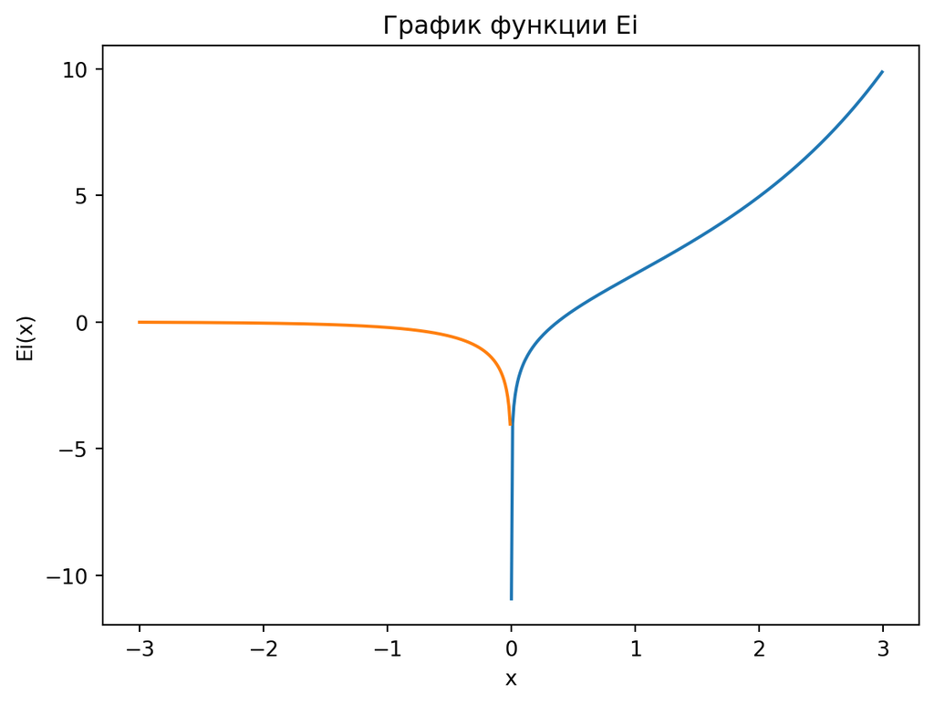

Рисунок 7: График функции интегральной экспоненты Ei

```python
# импортируем библиотеки для расчетов

# numpy используем для работы с массивами и подготовки данных для построения графиков.
# Также в некоторых функциях используем возможности векторных расчетов numpy
import numpy as np

# matplotlib используем для построения графиков
import matplotlib.pyplot as plt

# scipy.special используем как альтернативный вариант расчета специальных функций
import scipy.special as sc

# для скорости и удобства используем sc.expi
# построим ветки функции для положительных и отрицательных аргументов раздельно
x = np.arange(1e-5,3,0.01)
x1 = np.arange(-3,-1e-5,0.01)

plt.plot(x, sc.expi(x))
plt.plot(x1, sc.expi(x1))
plt.title("График функции Ei")
plt.xlabel("x")
plt.ylabel("Ei(x)")
plt.show()
```

Часто для проведения расчетов, особенно с использованием компьютерных библиотеке расчетов, бывает удобнее пользоваться модифицированной интегральной показательной функцией $Ei_1(x)$ или $E_1(x)$ или $Ei_n(x)$ при $n=1$.
$$Ei_n(x) = \int\limits_{1}^{\infty}\frac{e^{-tx}}{t^n}\,\mathrm dt$$

Функцию интегральной экспоненты можно представить в виде ряда.

$$Ei(x)=-\int\limits_{x}^{\infty}\frac{e^{-t}}{t}\,\mathrm dt=\gamma+\operatorname{ln}|-x|+\sum\limits_{n\ge1}\frac{{-x}^n}{n!\cdot n}, \; x\in\mathbb R,\;$$

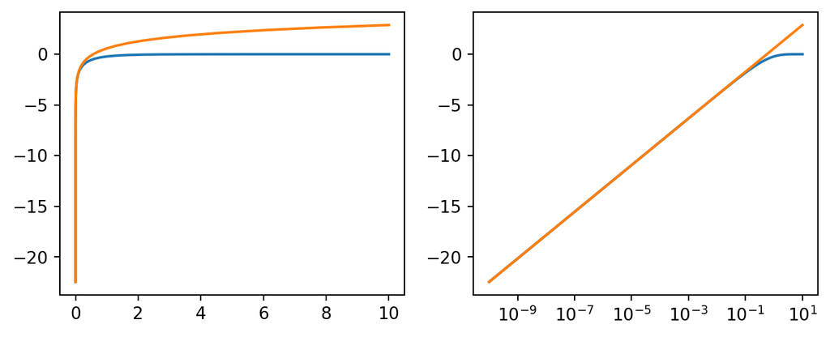

Рисунок 8: Сравнение Ei и ln для обычных и полулогарифмических координат

```python
# зададим логарифмическое распределение точек вблизи нуля для построения графика
x = np.logspace(-10, 1, 100)

plt.rcParams["figure.figsize"] = (8,3)
fig, (ax1, ax2) = plt.subplots(1, 2)
ax1.plot(x, sc.expi(-x))
ax1.plot(x, np.log(x) + 0.57721566481)
#ax1.set_title('Сравнение Ei и ln для обычных координат')

ax2.plot(x, sc.expi(-x))
ax2.plot(x, np.log(x)  + 0.57721566481)
ax2.set_xscale('log')
#ax2.set_title('Сравнение Ei и ln для полулогарифмических координат')

plt.show()
```

Из приведенного выражения можно сделать выводы, что для маленьких значений аргумента функция интегральной экспоненты $E_1(x)$ может быть аппроксимирована логарифмической зависимостью.

$$E_1(x) = -ln(x) - \gamma$$

График сравнения функций $E_1(x)$ и $ln(x)$ показан на Рисунок 8. Видно, что хорошей аппроксимация будет только для маленьких значений аргумента $x < 0.01$. Но для решения уравнения фильтрации именно эта зона представляет наибольший интерес.

Представление интегральной экспоненты в виде логарифмической аппроксимации удобно на практике, так как логарифм легче вычислять. В большинстве языков программирования и инструментов для проведения расчетов расчет логарифма реализован по умолчанию. А для расчета интегральной экспоненты, часто приходится предпринимать дополнительные шаги.

Решение уравнения фильтрации для линейного стока с учетом логарифмической аппроксимации можно представить в виде

$$p_D(r_D,t_D) = \frac{1}{2} \left( ln \left( \dfrac{ t_D }{r_D^2} \right) +0.809 \right)$$

при использовании данного уравнения, следует помнить, что приближенное решение применимо при $\dfrac{r_D^2}{4t_D} < 0.01$

Решение линейного стока в размерных переменных

$$p\left(r,t\right)=p_i-\frac{18.41q_sB\mu}{kh}\left(-\frac{1}{2}Ei\left(-\frac{\varphi\mu c_tr^2}{0.00144kt}\right)\right)$$

Решение с учетом логарифмической аппроксимации в размерных переменных

$$p\left(r,t\right)=p_i-\frac{9.205q_sB\mu}{kh}\left(ln{\frac{kt}{\varphi\mu c_tr^2}}-7.12\right)$$

верно при
$$\frac{kt}{\varphi\mu c_tr^2}>70000$$

Решения приведены для практических метрических единиц измерения, что можно увидеть по размерному коэффициенту.

Нестационарное решение с учетом скин-фактора будет иметь вид

$$P(r, t) = P_{i} - \frac {9.205 {q_s} B\mu }{k h}(\ ln\frac {k t}{ \varphi \mu {c_t} {r^2}} -7.12 + 2S)$$